# Data Sciences

Evolving Data, Statistical Thinking & Data Sovereignty

Brian Yandell ([*byandell.github.io*](https://byandell.github.io))

2026-08-31

# Data Sciences Overview

- What is Data Science?
- Making Sense of Data & Statistical Significance
- Data Sovereignty & Open Science
- Big Data & Data Repositories

# What is Data Science?

## Perspectives on Data Sciences

Data science approaches vary widely depending on context, discipline, background, goals, and available tools.

### My Journey

- Pure mathematics → Statistics → Data Science.
- Informal coding background driven by real-world research problems.
- Evolution from statistical consulting to interdisciplinary collaboration.
- Systems trajectory: Ecology → Agriculture → Health → Environment.

### Key Concepts

- Data sciences bridge **computational thinking**, **quantitative methods**, and **domain expertise**.
- Focus on how communities use data to understand health, environment, and local decision-making.
- Part of the broader effort to Document Digital Tools.

## Blog Perspectives: `byandell.github.io`

Insights from personal blog publications on the evolution of data science:

- **[What is Data Science?](https://byandell.github.io/What-is-Data-Science/)**: Framing data science as an evolving discipline blending math, statistics, computer science, and domain inquiry.
- **[Data Evolve](https://byandell.github.io/Data-Evolve)**: Tracing how tools, languages (S → R, Python, Julia), and algorithms evolve alongside data scale.
- **[Data Science Collaboratory](https://byandell.github.io/Data-Sciences-Collaboratory/)**: Moving from transactional consulting to deep collaborative partnerships across research domains.
- **[Data Science Across Liberal Arts](https://byandell.github.io/Data-Science-across-the-Liberal-Arts/)**: Broadening data literacy beyond STEM into humanities, ethics, and social inquiry.
- **[Strategic Planning](https://byandell.github.io/Data-Models-and-Statistics/)**: Integrating statistics, experimental design, and predictive models into organizational decision-making.
- **[Data Science Quotes](https://byandell.github.io/Useful-Data-Science-Quotes/)**: Principles of data visualization, statistical caution, and scientific reasoning.

## [What is Data Science?](https://byandell.github.io/What-is-Data-Science/)

### Defining the Discipline & Roles

- **Core Triangle**: Blends statistics, computer science, and applied math with deep domain inquiry.
- **Data Literacy vs. Science**: Literacy reads and communicates with data; data science develops methods to reveal new insights.
- **Roles in Practice**: Beyond titles (engineer vs. analyst vs. scientist), researchers are domain investigators tackling data mountains.

### Historical Lineage & Thought Forms

- **Biometry (Fisher, 1948)**: Active pursuit of biological knowledge by quantitative methods to understand variable phenomena.
- **Data Analysis (Tukey, 1962)**: Moving beyond pure mathematical theory to exploratory analysis and computer-aided display.
- **Iterative Investigation (Box, 1980)**: Statisticians as proactive partners in iterative deductive-inductive scientific inquiry.

## [Data Evolve](https://byandell.github.io/Data-Evolve)

### Data as a Process & Dynamic Verb

- **Data as a Verb**: Inspired by Lakota language (Jhon Goes-in-Center), viewing data not as static nouns but as living, evolving processes.
- **Contextual Meaning**: A single datum doesn’t change, but its context, metadata, and provenance evolve its value over time.
- **Harmonization**: Small data augmented by Big Data continually evolves the questions we are able to ask.

### The Evolution of Software & Tools

- **“Software Rots”**: Code cannot remain static; it must continuously adapt as data, systems, and questions shift.
- **Daryl Pregibon’s Progression**:
  - *Equation* → *Algorithm* → *Code/Function* → *Package* → *Standalone Interactive Widgets*.
- **Living Workflows**: Tools must facilitate direct collaboration and active exploration for domain scientists.

## [Data Sciences Collaboratory](https://byandell.github.io/Data-Sciences-Collaboratory/)

### From Consulting to Deep Collaboration

- **Transformational Partnerships**: Evolving beyond one-off statistical advice to embedded, co-designed research programs.
- **Team-Based Science**: Modern complex challenges (health, environment, energy) require interdisciplinary expertise across boundaries.
- **Early Engagement**: Framing and design planning before encountering IT and computation bottlenecks.

### Education, Training & Campus Infrastructure

- **Workforce Retraining**: Developing curriculum targeted at domain researchers swamped by high-throughput data.
- **Co-Advising Model**: Biometry MS model pairing students with mentors in both quantitative and biological fields.
- **Campus Collaboratories**: Open creative spaces linking campus research with high-throughput cyberinfrastructure (CHTC, ACI).

## [Data Science Across Liberal Arts](https://byandell.github.io/Data-Science-across-the-Liberal-Arts/)

### Data Literacy as a 21st Century Civic Need

- **Civic Literacy**: In an information age, liberal arts education requires data science to enable active, informed civic life.
- **Storytelling with Data**: Training a new generation to extract generalizable knowledge and tell meaningful, ethical stories.
- **Democratizing Access**: Expanding quantitative skills across humanities, journalism, sociology, and the arts.

### Deep Grounding to Address Wicked Problems

- **Context Dependence**: Technical methods are incomplete without deep grounding in history, culture, and domain knowledge.
- **Beyond Monolithic Degrees**: Fostering versatile domain experts equipped with agile computational and communication skills.
- **Tackling Complexities**: Addressing “wicked problems” through collaborative, cross-disciplinary synthesis.

## [Strategic Planning: Data, Models & Statistics](https://byandell.github.io/Data-Models-and-Statistics/)

### Statistics at the Center of the Data Surge

- **Sense-Making in the Information Age**: IT advances generate massive data, but statistical thinking translates noise into meaning.
- **Quantitative Core**: Statistical theory, experimental design, and modeling remain the bedrock of rigorous inquiry.
- **Methodological Gaps**: Massive modern datasets require developing new statistical methods rather than relying on legacy tools.

### George Box’s Departmental Vision

- **Core & Joint Architecture**: A strong central departmental core combined with specialists holding joint appointments across campus.
- **Direct Domain Impact**: Embedding statistical faculty in forefront research (virology, genetics, agriculture, medicine).
- **Institutional Strategy**: Continuous curriculum review and interdisciplinary alignment to meet emerging scientific needs.

## [Useful Data Science Quotes](https://byandell.github.io/Useful-Data-Science-Quotes/)

### Modeling, Skepticism & Design

- **George E.P. Box**: *“All models are wrong, but some models are useful.”* — Avoid falling blindly in love with models.
- **Gertrude M. Cox**: The greatest statistical contribution is often persuading the investigator to explain *why* they do an experiment.
- **Douglas M. Bates**: *“Statistics is the science of variation.”*

### Judgment, Reproducibility & Humility

- **John M. Barry**: Scientific progress relies on *judgment* to distinguish reproducible, expandable findings from tortured data.
- **Karl W. Broman**: High-dimensional biology requires tools enabling domain scientists to carry out their own investigations.
- **William Cowper**: *“Knowledge is proud that he has learned so much, Wisdom is humble that he knows no more.”*

# Making Sense of Data & Statistical Significance

## Significance vs. Importance

**Crucial Distinction**

**Statistical significance** measures whether an observed pattern could occur by chance under a null model. **Importance** addresses whether a result is meaningful, actionable, and relevant to the domain problem. - Statistical significance does **not** imply importance. - Importance does **not** depend solely on statistical significance. - Large sample sizes can produce highly “statistically significant” yet practically trivial effects.

- **Test or Plot?**: Plotting data first explores underlying patterns, non-linearities, and outliers before jumping to formal testing.
- Visualizations are more effective and informative than raw test summary tables.

## Scatter Plots & Relational Visualization

Scatter (*X-Y*) plots investigate relationships among measurements, augmented with color, symbol shape, trend lines, and facets.

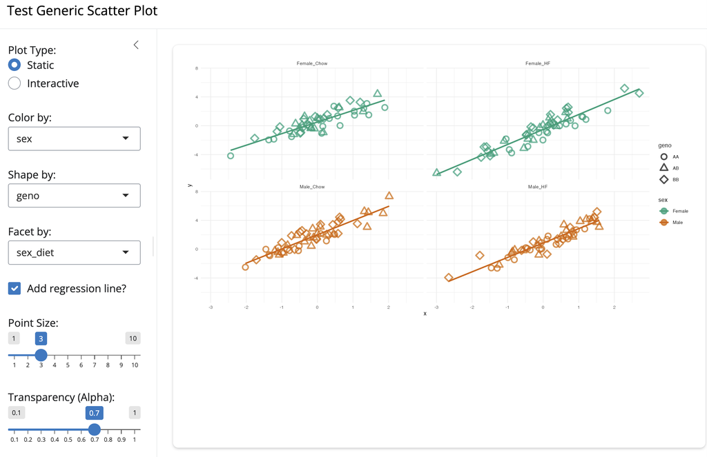

[`scattyr`](https://byandell.github.io/scattyr/) repo plots in `R` ([`ggplot2`](https://ggplot2.tidyverse.org/)) and `Python` ([`plotnine`](https://plotnine.readthedocs.io/)) with color, symbol shape, and facets to reveal data patterns.

## Analytical Pitfalls to Avoid

- **Spurious Association**: Confounding variables causing apparent relationships.
- **Multiple Testing**: Uncorrected testing across vast arrays of features guarantees false discoveries.
- **$p$-Hacking**: Data dredging or selective reporting to reach $p < 0.05$.

## Spatial & Temporal Autocorrelation

Complex environmental and biological systems present unique analytical challenges:

### Autocorrelation Challenges

- Measurements over space and time are inherently correlated.
- Nearby locations (e.g., rainfall in a valley) are autocorrelated.
- Arbitrary spatial/temporal resolution (daily vs. drought duration; land cover vs. county boundaries).
- Standard statistical independence assumptions often fail.

### Cumulative Measures

- Cumulative metrics (e.g., cumulative rain & drought) handle autocorrelation better than instantaneous rates.
- Example Case Study: [Rain & Drought Analysis](https://byandell.github.io/rainDrought/) examining Oglala Lakota (Pine Ridge) and Sicangu (Rosebud) counties using `plotnine` in Python.

## Cumulative Trajectories

[interactive chart not shown]

- single-click on a year to add/remove
- double-click on a year to isolate
- triple-click on a year to toggle isolate/remove
- click `Reset View` to reset

# Data Sovereignty & Open Science

## Balancing Open Data & Data Sovereignty

There is an ongoing tension between the **open data movement** and **data sovereignty**—the inherent right of Indigenous communities and local groups to govern data collected from their people, lands, and resources.

### Open Science

- Accelerates scientific discovery and reproducibility.
- Public data repositories and open algorithms.
- **FAIR Principles**: Findable, Accessible, Interoperable, Reusable.

### Data Sovereignty

- Protects community rights, privacy, and cultural heritage.
- Local governance and control over access/use.
- **CARE Principles**: Collective Benefit, Authority to Control, Responsibility, Ethics.

## Indigenous Data Governance Frameworks

Key initiatives and frameworks shaping Indigenous data science:

- **[Data Sovereignty](https://byandell.github.io/Data-Sovereignty/) & [Indigenous Data Science](https://byandell.github.io/pages/indigenous/)**: Synthesizing governance practices and sovereign data management.
- **[US Indigenous Data Network (USIDN)](https://usindigenousdatanetwork.org/)**: Supporting tribal data governance and capacity.
- **[Indigenous Data Alliance](https://indigenousdata.org/)**: Promoting Indigenous data rights globally.
- **[CARE Data Maturity Model](https://indigenousdatalab.org/care-data-maturity-model/)**: Evaluating organizational alignment with CARE principles.
- **[Tiered Sovereign Data Framework](https://atniclimate.github.io/TieredSovereignDataFramework/)**: Operationalizing tiered access controls for sovereign data.

# Big Data & Data Repositories

## Understanding Big Data: The 3 Vs, 6 Vs, and 3 Us

Big data refers to datasets exceeding the processing capacity of traditional database systems and analysis tools.

### Original 3 Vs

- **Volume**: Scale of data.
- **Velocity**: Speed of streaming/generation.
- **Variety**: Diversity of formats.

### Expanded 6 Vs

- **Veracity**: Trustworthiness.
- **Validity**: Accuracy.
- **Volatility**: Rate of change.

### Statistical 3 Us

- **Unknowns**: Unmeasured factors.
- **Uncertainty**: Measurement noise.
- **Unfamiliarity**: Novel data structures.

## Open Data Repositories & Resources

Platforms and repositories supporting modern data science workflows:

- **Open Science & AI Platforms**:
  - [Open Source Program Office (OSPO)](https://dsi.wisc.edu/initiatives/ospo/): UW-Madison open research initiative.
  - [Hugging Face](https://huggingface.co/): Open repository for machine learning models and datasets.
  - [Kaggle](https://www.kaggle.com/): Community platform for datasets, notebooks, and challenges.
- **Data Science Guides in this Site**:
  - Significance and Importance
  - Data Repositories
  - Big Data Reference

# Conclusion & Next Steps

## Summary & Learning Path

- **Statistical Thinking**: Prioritize data visualization and clear reasoning over blind statistical testing.
- **Contextual Awareness**: Account for spatial/temporal autocorrelation and cumulative effects.
- **Responsible Governance**: Balance FAIR open science with CARE Indigenous data sovereignty principles.
- **Explore Resources**: Visit the full Data Sciences Index and companion slide decks (R, Python, AI).

*byandell.github.io/Documentation*